# Distributed feature selection - *distfeatselect*

## Introduction

This algorithm is designed to perform feature selection on a given dataset using distributed scheme logic [[1]](https://link.springer.com/article/10.1007/s10994-019-05809-y). The goal is to help users streamline their feature selection process, potentially improving model performance and reducing dimensionality.

## Overview

The custom feature selection algorithm DFS is implemented as a scikit-learn-compatible transformer, following the scikit-learn API standards. It can be seamlessly integrated into scikit-learn workflows, allowing users to incorporate distributed feature selection into their machine learning pipelines.

## Usage

In this section, we will demonstrate how to use the dfs package and some of its functionality. This example uses the Breast Cancer Wisconsin (Diagnostic) Data Set (WDBC) dataset available [here](https://archive.ics.uci.edu/dataset/17/breast+cancer+wisconsin+diagnostic).

First, we import several essential Python libraries.

```python
import pandas as pd
import numpy as np
from sklearn.model_selection import train_test_split
from sklearn.preprocessing import MinMaxScaler
from sklearn.metrics import accuracy_score
from sklearn.svm import SVC
```

We install and import distfeatselect package.

```python
pip install distfeatselect
```

```
     ━━━━━━━━━━━━━━━━━━━━━━━━━━━━━━━━━━━━━━━━ 55.5/55.5 kB 1.1 MB/s eta 0:00:00
```

```python
from distfeatselect import utils
from distfeatselect import dfs
from distfeatselect import rfs
```

Then we'll import the data:

```python
pip install ucimlrepo
```

```python
from ucimlrepo import fetch_ucirepo

# fetch dataset
breast_cancer_wisconsin_diagnostic = fetch_ucirepo(id=17)

# data (as pandas dataframes)
X = breast_cancer_wisconsin_diagnostic.data.features
y = breast_cancer_wisconsin_diagnostic.data.targets
```

```python
y["Diagnosis"].replace({'M': 1, 'B': 0}, inplace=True)
```

We can preview the dataset:

```python
X.head()
```

|  | radius1 | texture1 | perimeter1 | area1 | smoothness1 | compactness1 | concavity1 | concave_points1 | symmetry1 | fractal_dimension1 | ... | radius3 | texture3 | perimeter3 | area3 | smoothness3 | compactness3 | concavity3 | concave_points3 | symmetry3 | fractal_dimension3 |
| --- | --- | --- | --- | --- | --- | --- | --- | --- | --- | --- | --- | --- | --- | --- | --- | --- | --- | --- | --- | --- | --- |
| 0 | 17.99 | 10.38 | 122.80 | 1001.0 | 0.11840 | 0.27760 | 0.3001 | 0.14710 | 0.2419 | 0.07871 | ... | 25.38 | 17.33 | 184.60 | 2019.0 | 0.1622 | 0.6656 | 0.7119 | 0.2654 | 0.4601 | 0.11890 |
| 1 | 20.57 | 17.77 | 132.90 | 1326.0 | 0.08474 | 0.07864 | 0.0869 | 0.07017 | 0.1812 | 0.05667 | ... | 24.99 | 23.41 | 158.80 | 1956.0 | 0.1238 | 0.1866 | 0.2416 | 0.1860 | 0.2750 | 0.08902 |
| 2 | 19.69 | 21.25 | 130.00 | 1203.0 | 0.10960 | 0.15990 | 0.1974 | 0.12790 | 0.2069 | 0.05999 | ... | 23.57 | 25.53 | 152.50 | 1709.0 | 0.1444 | 0.4245 | 0.4504 | 0.2430 | 0.3613 | 0.08758 |
| 3 | 11.42 | 20.38 | 77.58 | 386.1 | 0.14250 | 0.28390 | 0.2414 | 0.10520 | 0.2597 | 0.09744 | ... | 14.91 | 26.50 | 98.87 | 567.7 | 0.2098 | 0.8663 | 0.6869 | 0.2575 | 0.6638 | 0.17300 |
| 4 | 20.29 | 14.34 | 135.10 | 1297.0 | 0.10030 | 0.13280 | 0.1980 | 0.10430 | 0.1809 | 0.05883 | ... | 22.54 | 16.67 | 152.20 | 1575.0 | 0.1374 | 0.2050 | 0.4000 | 0.1625 | 0.2364 | 0.07678 |

5 rows × 30 columns

As an additional step, we highly recommend performing correlation analysis and removing desired correlated features. In this example, a correlation heatmap is plotted to find highly correlated features and remove them.

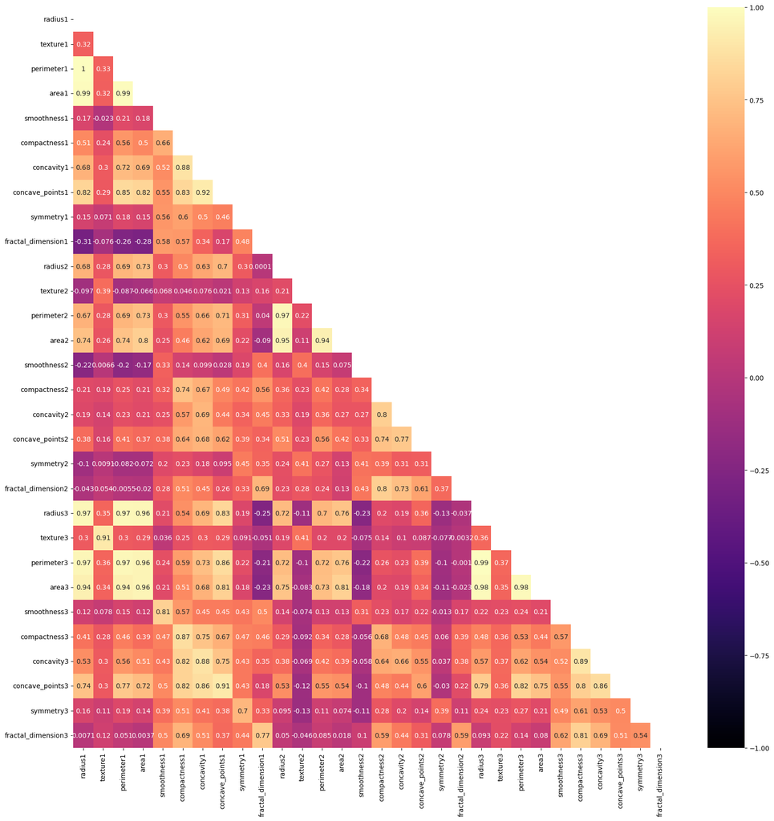

```python
import seaborn as sns # seaborn not included as dfsc dependency
import matplotlib.pyplot as plt #pyplot not included as dfsc dependency

plt.figure(figsize=(20,20))

# Generate a mask to onlyshow the bottom triangle
mask = np.triu(np.ones_like(X.corr(), dtype=bool))

# generate heatmap
sns.heatmap(X.corr(), annot=True, mask=mask, vmin=-1, vmax=1, cmap='magma')
plt.show()
```

Using information from the heatmap we can optionally remove all the highly correlated features.

```python
#coldrop = ['radius1', 'concave_points1'] identify all the features that are highly correlated and add them to the list of features to be dropped
#X = X.drop(columns=coldrop)
```

The data is then segmented into training and testing portions to be utilized by DFSC. This standard process is carried out using scikit-learn's train_test_split function.

```python
X_train, X_test, y_train, y_test = train_test_split(X, y, test_size=0.2, random_state=42, stratify=y)
```

Preprocessing - we can incorporate various preprocessing steps using standard methods and packages such as [sklearn.preprocessing](https://scikit-learn.org/stable/modules/preprocessing.html#preprocessing-data). Here, we scaled the data using MinMaxScaler.

```python
minmax = MinMaxScaler(feature_range=(0, 1))
X_train = minmax.fit_transform(X_train)
X_test = minmax.fit_transform(X_test)
```

We convert the column vectors y_train and y_test into 1D arrays. This step is optional, but if skipped, you will receive warnings

```python
y_train = np.ravel(y_train)
y_test = np.ravel(y_test)
```

## Example of typical usage

DFSC follows the sklearn model API. We create an instance of the DFSC class and then call its methods.

We fit the model by instantiating a new *DFSC* object. All wanted settings are passed into the constructor. Then you call its *fit* method and pass in the training data and corresponding labels.

*More details about settings (the parameters) available for the DFSC constructor are available in the docstrings, for example, via help(DFSC), help(DFSC.fit) ...*

```python
dfs_model = dfs.DFS(n_vbins=2, n_hbins=1, n_runs=5, redistribute_features=True)

fitted_model = dfs_model.fit(X_train, y_train)
```

```
New best model for hbin 0. roc_auc=0.92595 -- Model features [20, 23, 26]
All horizontal partitions have converged. Final iter count: 3
Optimization terminated successfully    (Exit mode 0)
            Current function value: 0.2794015102275302
            Iterations: 73
            Function evaluations: 73
            Gradient evaluations: 73
```

Now, we can get a mask, or integer index, of the features selected. We call *get_support* method. Here, we call it with True as a parameter and the return value will be an array of integers.

```python
selected_features = dfs_model.get_support(True)
```

If we want to reduce the dataset to the selected features, we call *transform* method.

```python
X_train_transformed = dfs_model.transform(X_train)
X_test_transformed = dfs_model.transform(X_test)
```

We can now do a standard process for the task of classification using whatever classifier and metrics we want.

```python
svm_classifier = SVC(kernel='linear')
svm_classifier.fit(X_train_transformed, y_train)

y_pred = svm_classifier.predict(X_test_transformed)

# Calculate metrics
accuracy = accuracy_score(y_test, y_pred)

print(f"Selected features {selected_features}\n")
print(f"Accuracy {accuracy} \n")
```

```
Selected features [20, 23, 26]

Accuracy 0.956140350877193
```

## Example of using Random Feature Selection (*RFSC*)

*RFSC* as a base (local) feature selection algorithm inside distributed scheme (*DFSC*)

RFSC can be used as a feature selection algorithm on its own or as shown below as a base fs algorithm for DFSC.

First, we instantiate a new RFSC object using distance correlation as a method. We also set number of models as 300, number of iterations as 100 and rip threshold for feature inclusion in the final model as 0.9.

*More details about settings (the parameters) available for RFSC constructor are available in the docstrings, for example, via help(RFSC).*

```python
rfs_model = rfs.RFS(n_models=300, n_iters=100, rip_cutoff=0.9, method = "dcor")
```

Now, we set rfsc as a local_fs_method in new DFSC object and continue the same as shown in previous example. Instead of rfsc, we could also set local_fs_method to be some other custom or wellknown feature selection algorithm. The only prerequisite for that is that the algorithm follows the sklearn API standards.

```python
dfs_model = dfs.DFS(n_vbins=3, n_hbins= 2, n_runs= 10, max_processes= 6, local_fs_method= rfs_model, redistribute_features= True)

fitted_model = dfs_model.fit(X_train, y_train)
features = dfs_model.get_support(True)
```

```
New best model for hbin 1. roc_auc=0.85852 -- Model features [0, 2, 10, 27]
New best model for hbin 0. roc_auc=0.86222 -- Model features [2, 27]
New best model for hbin 0. roc_auc=0.86385 -- Model features [7, 20]
New best model for hbin 1. roc_auc=0.87424 -- Model features [7, 12, 20, 22]
New best model for hbin 0. roc_auc=0.8765 -- Model features [7, 20, 22, 27]
New best model for hbin 1. roc_auc=0.87478 -- Model features [7, 10, 20, 22]
All horizontal partitions have converged. Final iter count: 4
Optimization terminated successfully    (Exit mode 0)
            Current function value: 0.5410368798991855
            Iterations: 68
            Function evaluations: 68
            Gradient evaluations: 68
```

To reduce dataset to the selected features, we call *transform* method.

```python
X_train_transformed = dfs_model.transform(X_train)
X_test_transformed = dfs_model.transform(X_test)
```

We can now do standard process for the task of classification using whatever classifier and metrics we want.

```python
svm_classifier = SVC(kernel='linear')
svm_classifier.fit(X_train_transformed, y_train)

y_pred = svm_classifier.predict(X_test_transformed)

# Calculate metrics
accuracy = accuracy_score(y_test, y_pred)

print(f"Selected features {selected_features}\n")
print(f"Accuracy {accuracy} \n")
```

```
Selected features [20, 23, 26]

Accuracy 0.9649122807017544
```

## Example of using the algorithm with [sklearn.pipeline.Pipeline](https://scikit-learn.org/stable/modules/generated/sklearn.pipeline.Pipeline.html#sklearn-pipeline-pipeline) and [sklearn.model_selection.GridSearchCV](https://scikit-learn.org/stable/modules/generated/sklearn.model_selection.GridSearchCV.html)

We can also incorporate either of this two algorithms RFSC or DFSC into sklearn pipeline and do the hyperparameters tuning using GridSearchCV as shown in the following example.

```python
from sklearn.pipeline import Pipeline
from sklearn.preprocessing import StandardScaler
from sklearn.model_selection import GridSearchCV
from sklearn.linear_model import LogisticRegression
```

Define the parameter grid for hyperparameter tuning.

```python
param_grid = {
    'custom_feature_selector__n_iters': [1, 5, 10],
    'custom_feature_selector__n_models': [2, 100]
}
```

Create the pipeline with RFSC as a custom feature selector.

```python
custom_feature_pipeline = Pipeline([
    ('scaler', StandardScaler()),
    ('custom_feature_selector', rfs.RFS()),
    ('classifier', LogisticRegression())
])
```

Create the GridSearchCV object.

```python
grid_search = GridSearchCV(custom_feature_pipeline, param_grid, cv=5)
```

Fit the GridSearchCV object to the data

```python
grid_search.fit(X_train, y_train)
```

[output not shown]

[output cut: 110 more lines]

[output not shown]

```
GridSearchCV(cv=5,
             estimator=Pipeline(steps=[('scaler', StandardScaler()),
                                       ('custom_feature_selector', RFS()),
                                       ('classifier', LogisticRegression())]),
             param_grid={'custom_feature_selector__n_iters': [1, 5, 10],
                         'custom_feature_selector__n_models': [2, 100]})
```

Get the best parameters and best score from the grid search.

```python
best_params = grid_search.best_params_
best_score = grid_search.best_score_

print("Best Parameters:", best_params)
print("Best Score:", best_score)
```

```
Best Parameters: {'custom_feature_selector__n_iters': 1, 'custom_feature_selector__n_models': 100}
Best Score: 0.9736263736263737
```

[1] Brankovic, A., Piroddi, L. (2019). [A distributed feature selection scheme with partial information sharing](https://link.springer.com/article/10.1007/s10994-019-05809-y)